# FOR/STT 875, Exercise 5

7/23/2019

## Learning objectives

- Practice with lists, data frames, and associated functions
- Summarize variables held in lists and data frames
- Work with R’s linear regression `lm` function output
- Review logical subsetting of vectors for partitioning and assigning of new values
- Generate and visualize data from mathematical functions

## Overview

Modify this R Markdown file by filling in the code needed to answer the questions.

## Submission instructions

Upload your exercise_5.Rmd and exercise_5.html files to the Exercise 5 D2L dropbox.

## Grading

You will receive full credit if your R Markdown document: 1) compiles without error; and 2) correctly completes the `# TODO:` code chunks. Also, please, fill in the feedback questions at the end of the exercise.

## Getting started

Again, set some global options to make the R code printed in the HTML output look nice.

```r
knitr::opts_chunk$set(comment = NA, tidy = TRUE)
```

## Lists

The `lm` function fits a linear model and returns a list containing elements such as the coefficients of the fitted model, the residual values, etc. Built in to R is a dataset with the fertility rate and several socioeconomic variables for 47 French-speaking provinces in Switzerland from the late 1800s. Of interest is how the socioeconomic values are related to the fertility rate. First we make the data available, and take a quick look.

```r
data(swiss)
str(swiss)
```

```
'data.frame':   47 obs. of  6 variables:
 $ Fertility       : num  80.2 83.1 92.5 85.8 76.9 76.1 83.8 92.4 82.4 82.9 ...
 $ Agriculture     : num  17 45.1 39.7 36.5 43.5 35.3 70.2 67.8 53.3 45.2 ...
 $ Examination     : int  15 6 5 12 17 9 16 14 12 16 ...
 $ Education       : int  12 9 5 7 15 7 7 8 7 13 ...
 $ Catholic        : num  9.96 84.84 93.4 33.77 5.16 ...
 $ Infant.Mortality: num  22.2 22.2 20.2 20.3 20.6 26.6 23.6 24.9 21 24.4 ...
```

```r
head(swiss)
```

```
             Fertility Agriculture Examination Education Catholic
Courtelary        80.2        17.0          15        12     9.96
Delemont          83.1        45.1           6         9    84.84
Franches-Mnt      92.5        39.7           5         5    93.40
Moutier           85.8        36.5          12         7    33.77
Neuveville        76.9        43.5          17        15     5.16
Porrentruy        76.1        35.3           9         7    90.57
             Infant.Mortality
Courtelary               22.2
Delemont                 22.2
Franches-Mnt             20.2
Moutier                  20.3
Neuveville               20.6
Porrentruy               26.6
```

```r
cor(swiss)
```

```
                  Fertility Agriculture Examination   Education   Catholic
Fertility         1.0000000  0.35307918  -0.6458827 -0.66378886  0.4636847
Agriculture       0.3530792  1.00000000  -0.6865422 -0.63952252  0.4010951
Examination      -0.6458827 -0.68654221   1.0000000  0.69841530 -0.5727418
Education        -0.6637889 -0.63952252   0.6984153  1.00000000 -0.1538589
Catholic          0.4636847  0.40109505  -0.5727418 -0.15385892  1.0000000
Infant.Mortality  0.4165560 -0.06085861  -0.1140216 -0.09932185  0.1754959
                 Infant.Mortality
Fertility              0.41655603
Agriculture           -0.06085861
Examination           -0.11402160
Education             -0.09932185
Catholic               0.17549591
Infant.Mortality       1.00000000
```

From the correlation matrix we see that `Education` has the strongest correlation with `Fertility`. Next we draw a scatter plot of the two variables to assess linearity. Here are two different ways to request the scatter plot. The second matches the syntax for specifying a linear model in the `lm` function.

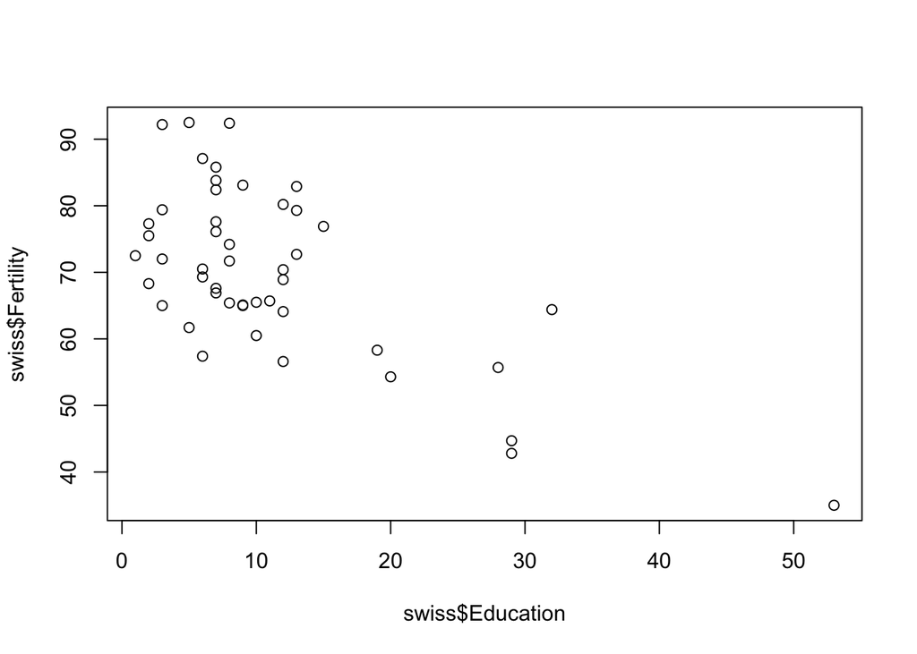

```r
plot(swiss$Education, swiss$Fertility)
```

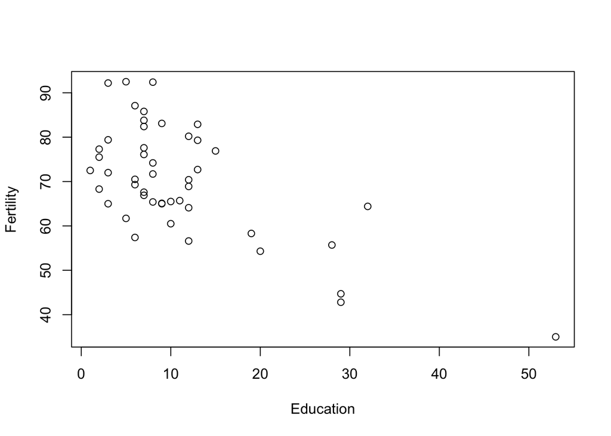

```r
plot(Fertility ~ Education, data = swiss)
```

The scatter plots don’t give major causes for concern, although it looks like the outlier at the bottom right influences the correlation and the slope of a fitted least squares line substantially, but we will ignore those issues and press ahead. Next we fit a linear model, assign it to the R object `swiss.lm`, ask whether the object is a list, and obtain the names of the elements of `swiss.lm`.

```r
swiss.lm <- lm(Fertility ~ Education, data = swiss)
is.list(swiss.lm)
```

```
[1] TRUE
```

```r
names(swiss.lm)
```

```
 [1] "coefficients"  "residuals"     "effects"       "rank"
 [5] "fitted.values" "assign"        "qr"            "df.residual"
 [9] "xlevels"       "call"          "terms"         "model"
```

We see that `swiss.lm` is a list with 12 components.

We can extract the components in several ways. First we will use the `$` method, familiar from working with data frames. For example `swiss.lm$residuals` returns the residuals from the model. Use this method to extract the coefficients and the residuals from the model. Assign the results to R objects called `swiss.lm.coef.1` and `swiss.lm.resid.1`.

```r
swiss.lm.coef.1 <- swiss.lm$coefficients
swiss.lm.resid.1 <- swiss.lm$residuals
```

Now display the coefficients and the residuals.

```r
swiss.lm.coef.1
```

```
(Intercept)   Education
 79.6100585  -0.8623503
```

```r
swiss.lm.resid.1
```

```
  Courtelary     Delemont Franches-Mnt      Moutier   Neuveville
  10.9381450   11.2510941   17.2016929   12.2263935   10.2251959
  Porrentruy        Broye        Glane      Gruyere       Sarine
   2.5263935   10.2263935   19.6887438    8.8263935   14.5004953
     Veveyse        Aigle      Aubonne     Avenches     Cossonay
  12.6640432   -5.1618550   -6.6736065   -0.3618550  -13.5983071
   Echallens     Grandson     Lausanne    La Vallee       Lavaux
  -9.5853579   -1.0112562    0.2357497   -8.0630527   -6.7489059
      Morges       Moudon        Nyone         Orbe         Oron
  -5.4865556  -12.0230077  -12.6618550  -17.0359568   -6.2477082
     Payerne Paysd'enhaut        Rolle        Vevey      Yverdon
   1.4887438   -5.0230077  -10.4865556   -4.9254030   -7.3112562
     Conthey    Entremont       Herens     Martigwy      Monthey
  -2.3853579   -5.1359568   -0.5853579   -3.9359568    2.3769923
  St Maurice       Sierre         Sion       Boudry La Chauxdfnd
  -6.8489059   15.1769923   10.9004953    1.1381450   -4.4242053
    Le Locle    Neuchatel   Val de Ruz ValdeTravers V. De Geneve
   4.3004953   12.3851508    4.0263935   -5.9736065    1.0945070
 Rive Droite  Rive Gauche
  -9.9019000  -11.8019000
```

We might expect that the resulting objects are vectors. Use `is.vector` to test whether this is the case.

```r
is.vector(swiss.lm.coef.1)
```

```
[1] TRUE
```

```r
is.vector(swiss.lm.resid.1)
```

```
[1] TRUE
```

There are several other ways to extract components of a list. Here are a few ways to extract the coefficients.

1. `swiss.lm$coefficients`
2. `swiss.lm[["coefficients"]]`
3. `swiss.lm["coefficients"]`

(We could also use the number `1` in place of `"coefficients"` in (2) and (3).)

We’ve already used method 1 and assigned the result to `swiss.lm.coef.1`. Use the second and third methods, and assign the results to `swiss.lm.coef.2` and `swiss.lm.coef.3`. Also display all three results below.

```r
# TODO 5.1: Create swiss.lm.coef.2 and swiss.lm.coef.3 here, then print swiss.lm.coef.1, swiss.lm.coef.2, and swiss.lm.coef.3
swiss.lm.coef.2 <- swiss.lm[["coefficients"]]
swiss.lm.coef.3 <- swiss.lm["coefficients"]
# Print
swiss.lm.coef.1
```

```
(Intercept)   Education
 79.6100585  -0.8623503
```

```r
swiss.lm.coef.2
```

```
(Intercept)   Education
 79.6100585  -0.8623503
```

```r
swiss.lm.coef.3
```

```
$coefficients
(Intercept)   Education
 79.6100585  -0.8623503
```

Do the resulting objects look any different? Use `is.vector` and `is.list` on each of the three objects to determine whether they are vectors or lists.

```r
# TODO 5.2: Apply is.vector and is.list on swiss.lm.coef.1, swiss.lm.coef.2, and swiss.lm.coef.3 here
is.vector(swiss.lm.coef.1)
```

```
[1] TRUE
```

```r
is.vector(swiss.lm.coef.2)
```

```
[1] TRUE
```

```r
is.vector(swiss.lm.coef.3)
```

```
[1] TRUE
```

```r
is.list(swiss.lm.coef.1)
```

```
[1] FALSE
```

```r
is.list(swiss.lm.coef.2)
```

```
[1] FALSE
```

```r
is.list(swiss.lm.coef.3)
```

```
[1] TRUE
```

You should have discovered that Methods 1 and 2 returned a vector, but Method 3 returned a list. The difference may seem subtle and not particularly important, but it will become much more important when we start to write our own functions.

## Subsetting with logical vectors

Subsetting with logical vectors is an essential skill. We’ll practice this using the `gapminder` data frame.

```r
gapminder <- read.delim("http://blue.for.msu.edu/FOR875/data/gapminder.tsv")
str(gapminder)
```

```
'data.frame':   1704 obs. of  6 variables:
 $ country  : Factor w/ 142 levels "Afghanistan",..: 1 1 1 1 1 1 1 1 1 1 ...
 $ year     : int  1952 1957 1962 1967 1972 1977 1982 1987 1992 1997 ...
 $ pop      : num  8425333 9240934 10267083 11537966 13079460 ...
 $ continent: Factor w/ 5 levels "Africa","Americas",..: 3 3 3 3 3 3 3 3 3 3 ...
 $ lifeExp  : num  28.8 30.3 32 34 36.1 ...
 $ gdpPercap: num  779 821 853 836 740 ...
```

Here are two examples.

First we compute the mean population of France for the years contained in the dataset.

```r
mean(gapminder$pop[gapminder$country == "France"])
```

```
[1] 52952564
```

Next we extract the countries in the continent `Africa`. Since the countries are repeated for each of the years, we’ll use `unique` to list the countries only once.

```r
unique(gapminder$country[gapminder$continent == "Africa"])
```

```
 [1] Algeria                  Angola
 [3] Benin                    Botswana
 [5] Burkina Faso             Burundi
 [7] Cameroon                 Central African Republic
 [9] Chad                     Comoros
[11] Congo, Dem. Rep.         Congo, Rep.
[13] Cote d'Ivoire            Djibouti
[15] Egypt                    Equatorial Guinea
[17] Eritrea                  Ethiopia
[19] Gabon                    Gambia
[21] Ghana                    Guinea
[23] Guinea-Bissau            Kenya
[25] Lesotho                  Liberia
[27] Libya                    Madagascar
[29] Malawi                   Mali
[31] Mauritania               Mauritius
[33] Morocco                  Mozambique
[35] Namibia                  Niger
[37] Nigeria                  Reunion
[39] Rwanda                   Sao Tome and Principe
[41] Senegal                  Sierra Leone
[43] Somalia                  South Africa
[45] Sudan                    Swaziland
[47] Tanzania                 Togo
[49] Tunisia                  Uganda
[51] Zambia                   Zimbabwe
142 Levels: Afghanistan Albania Algeria Angola Argentina ... Zimbabwe
```

Next, draw a boxplot of the GDP for the year 1952.

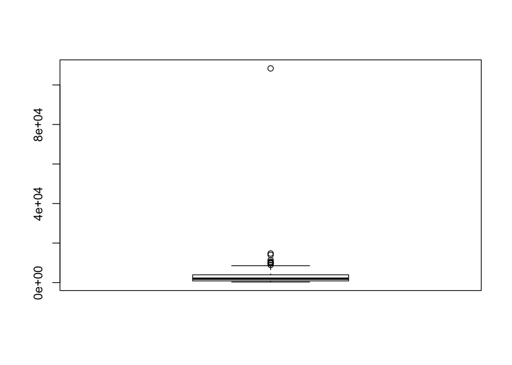

```r
boxplot(gapminder$gdpPercap[gapminder$year == 1952])
```

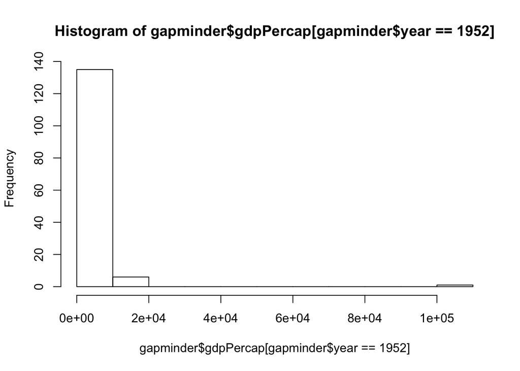

```r
hist(gapminder$gdpPercap[gapminder$year == 1952])
```

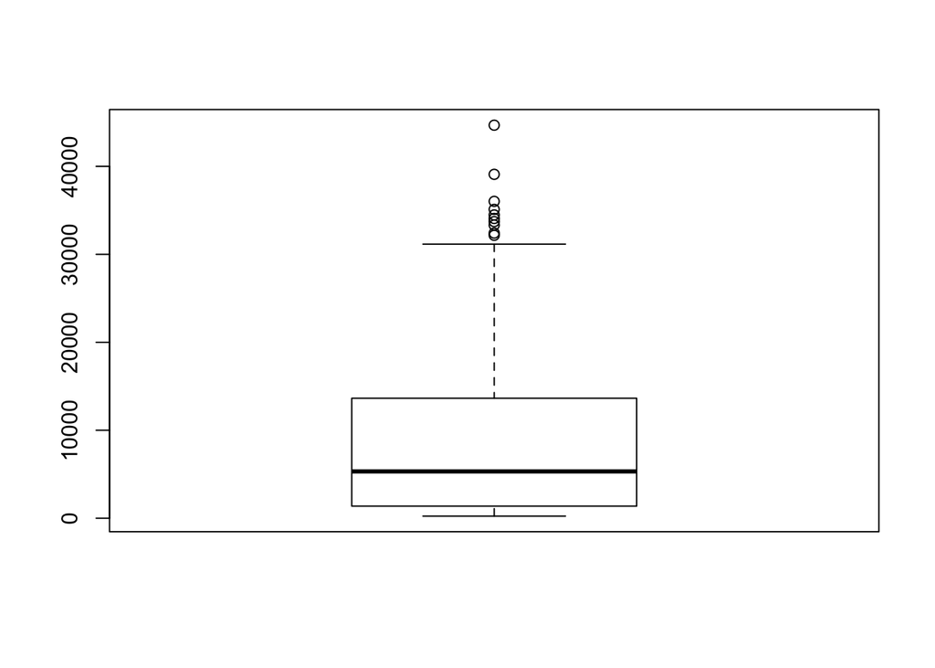

```r
boxplot(gapminder$gdpPercap[gapminder$year == 2002])
```

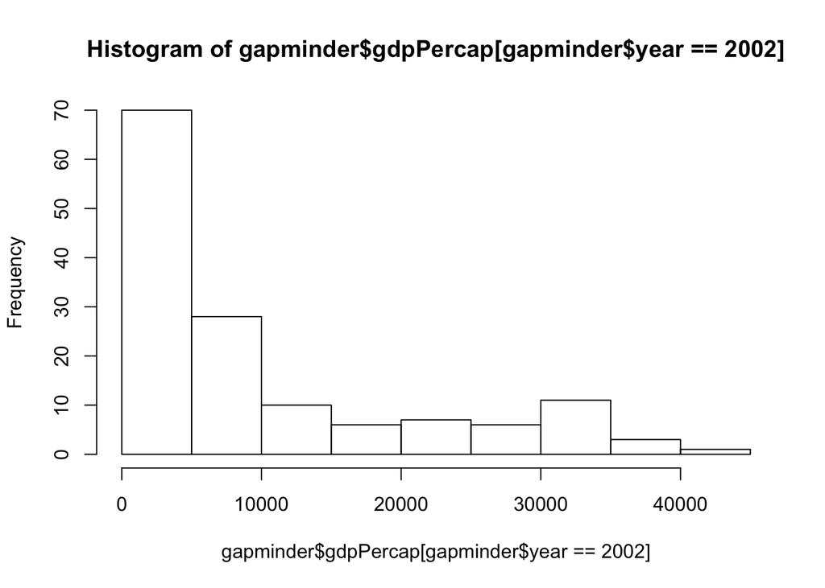

```r
hist(gapminder$gdpPercap[gapminder$year == 2002])
```

We can combine conditions with the operators `&` and `|` which represent “and” and “or” for vectors. For example, here’s how to extract all the countries whose population is more than 150 million in the year 1992.

```r
gapminder$country[gapminder$pop > 150000000 & gapminder$year == 1992]
```

```
[1] Brazil        China         India         Indonesia     United States
142 Levels: Afghanistan Albania Algeria Angola Argentina ... Zimbabwe
```

Use these ideas to extract the population of all countries whose life expectancy is more than 70 years, during 1967.

```r
# TODO 5.3: Add code to get the population of all countries meeting the noted conditions
gapminder$pop[gapminder$lifeExp > 70 & gapminder$year == 1967]
```

```
 [1]  11872264   7376998   9556500   8310226  20819767   9835109   4838800
 [8]  49569000  76368453   8716441    198676   2900100   2693585  52667100
[15] 100825279  12596822   2728150   3786019   2648961   4442238  32850275
[22]   7867931   6063000  54959000 198712000
```

Another useful operator is `%in%`. For example here’s how to compute the mean population for the United States, Mexico, and Canada during 1997.

```r
mean(gapminder$pop[gapminder$country %in% c("United States", "Mexico", "Canada") & gapminder$year == 1997])
```

```
[1] 133037583
```

Subscripting also can be used to change values of existing R objects as in the following example.

```r
dd <- data.frame(x = c("dog", "cat", "oink", "pig", "oink", "cat", "dog", "cat", "dog"), y = c("dog", "cat", "cat", "pig", "cow", "dog", "dog", "cat", "pig"), stringsAsFactors = FALSE)
dd
```

```
     x   y
1  dog dog
2  cat cat
3 oink cat
4  pig pig
5 oink cow
6  cat dog
7  dog dog
8  cat cat
9  dog pig
```

```r
dd$x[dd$x == "oink"] <- "pig"
dd
```

```
    x   y
1 dog dog
2 cat cat
3 pig cat
4 pig pig
5 pig cow
6 cat dog
7 dog dog
8 cat cat
9 dog pig
```

```r
dim(dd)
```

```
[1] 9 2
```

```r
dd$same <- rep("no", dim(dd)[1])
dd
```

```
    x   y same
1 dog dog   no
2 cat cat   no
3 pig cat   no
4 pig pig   no
5 pig cow   no
6 cat dog   no
7 dog dog   no
8 cat cat   no
9 dog pig   no
```

```r
dd$same[dd$x == dd$y] <- "yes"
dd
```

```
    x   y same
1 dog dog  yes
2 cat cat  yes
3 pig cat   no
4 pig pig  yes
5 pig cow   no
6 cat dog   no
7 dog dog  yes
8 cat cat  yes
9 dog pig   no
```

Next we will add a variable called `G8` to the `gapminder` data frame which will be equal to 1 or 0 depending on whether the country is in the G8 group of nations, which includes France, Germany, Italy, the United Kingdom, Japan, the United States, Canada, and Russia.

First, create a variable called `G8`, all of whose values are 0, in the gapminder data frame.

```r
# TODO 5.4: Add the G8 variable to the gapminder data frame here
gapminder$G8 <- rep(0, length.out = dim(gapminder)[1])
```

Now set `G8` equal to 1 if the country is in the G8. One way to do this is to give 8 separate R commands, one for each of the G8 countries. Another is to use `%in%` and complete the work in one line.

```r
# TODO 5.5: Set the G8 variable to 1 for G8 countries here
gapminder$G8[gapminder$country %in% c("France", "Germany", "Italy", "United Kingdom", "Japan", "United States", "Canada", "Russia")] <- 1
head(gapminder)
```

```
      country year      pop continent lifeExp gdpPercap G8
1 Afghanistan 1952  8425333      Asia  28.801  779.4453  0
2 Afghanistan 1957  9240934      Asia  30.332  820.8530  0
3 Afghanistan 1962 10267083      Asia  31.997  853.1007  0
4 Afghanistan 1967 11537966      Asia  34.020  836.1971  0
5 Afghanistan 1972 13079460      Asia  36.088  739.9811  0
6 Afghanistan 1977 14880372      Asia  38.438  786.1134  0
```

## Patterned data

We’ll plot the function $f(x) = \cos(x)$ for $x$ between $-2\pi$ and $2\pi$.

First, create a vector `x` containing 1000 equally spaced values between $-2\pi$ and $2\pi$ using the `seq` function.

```r
##Create x here
x <- seq(from=-2*pi, to=2*pi, length.out=1000)
```

Next use the `plot` command to plot the function. The first argument to `plot` should be the vector `x` we just created. The second argument should be `cos(x)`.

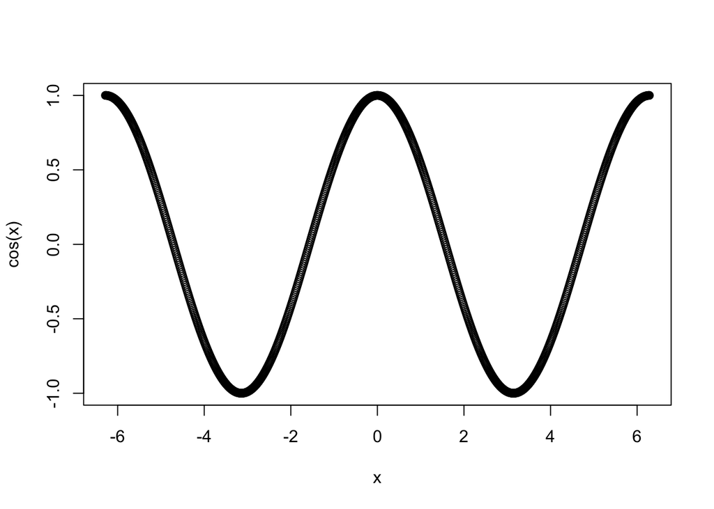

```r
# TODO 5.6: Draw the plot here
x<- seq(from = -2*pi, to = 2*pi, length.out = 1000)
plot(x, y=cos(x))
```

The graphic is OK, but since we’re plotting the graph of a function, we should connect the points rather than plotting each of the points. Add the argument `type = "l"` to accomplish this.

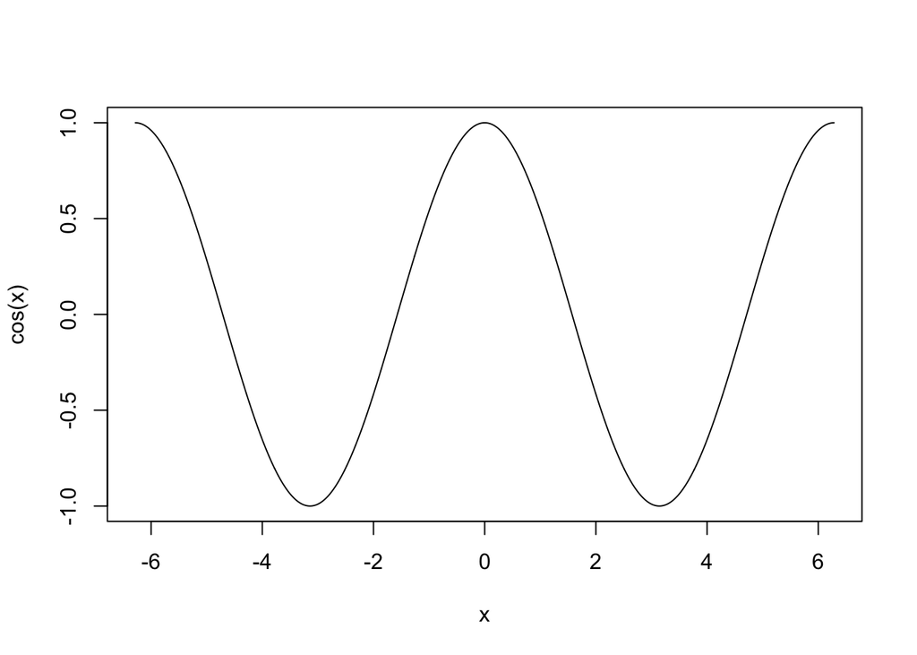

```r
# TODO 5.7: Draw the second plot here
x<- seq(from = -2*pi, to = 2*pi, length.out = 1000)
plot(x, y=cos(x), type = "l")
```

As seen in the G8 example above, `rep` is another very useful function for generating patterned data. The `rep` function replicates its first argument. Important arguments include `length.out`, `times`, and `each`. Some examples:

```r
ltrs <- c("a", "b", "q", "z")
rep(ltrs, length.out = 9)
```

```
[1] "a" "b" "q" "z" "a" "b" "q" "z" "a"
```

```r
rep(ltrs, each = 3)
```

```
 [1] "a" "a" "a" "b" "b" "b" "q" "q" "q" "z" "z" "z"
```

```r
rep(ltrs, times = 3)
```

```
 [1] "a" "b" "q" "z" "a" "b" "q" "z" "a" "b" "q" "z"
```

```r
rep(ltrs, times = c(3, 2, 4, 7))
```

```
 [1] "a" "a" "a" "b" "b" "q" "q" "q" "q" "z" "z" "z" "z" "z" "z" "z"
```

Congratulations! You’ve reached the end of Exercise 5.

If you have any lingering questions about the material in this document or in the corresponding chapter, put them here.

*None*

1. How do you feel you’re doing in this class?

*Piazza is really helpful. Found out all my questions had been asked by other classmates and had the answers already.*

2. What could be done to improve your learning experience?

*None. Perfect!*